# Results of model-based estimation for LLSIMBUM by trip for Blue marlin, scenario s1

2025-11-06

The input settings for model-based estimation applied to Blue marlin ( Makaira nigricans ) catch were as follows.

- Most complex model considered y ~ Year + area
- Simplest model considered y ~ Year
- Models fit successfuly using TMBnbinom1 TMBtweedie
- Best predictor variable in each model group selected with BIC
- Cross-validation results generated
- Variance calculated by Simulate
- All catch predicted by the models

### Model comparison

Table 1. Formula of BIC best model, along whether models were fit successfully. A dash (-) means the model converged. Failure to converge may be from data (not all years had a positive observation for delta models), fit (models did not converge) or CV (bycatch estimates had very large CVs). The cross-validation RMSE and mean ME across folds are shown (near zero is better).

| model | formula | RMSE | ME | Failure |
| --- | --- | --- | --- | --- |
| TMBnbinom1 | area + 1 + Year + offset(log(Effort)) | 0.0677 | -8e-04 | - |
| TMBtweedie | area + 1 + Year | 0.0688 | 0e+00 | - |

Table 2. DHARMa residual tests, where significant P values may indicate poor model specification. For detailed information on each row see Appendix in User Guide.

|  | TMBnbinom1 | TMBtweedie |
| --- | --- | --- |
| KS.D | 0.03 | 0.06 |
| KS.p | 0.83 | 0.18 |
| Dispersion.ratio | 1.46 | 1.47 |
| Dispersion.p | 0.02 | 0.00 |
| ZeroInf.ratio | 0.96 | 0.97 |
| ZeroInf.p | 0.54 | 0.61 |
| Outlier | 5.00 | 8.00 |
| Outlier.p | 0.08 | 0.01 |

Table 3. Parameters from fitted models, along with loglikelihood and residual degrees of freedom. The scale parameter is the residual standard deviation for normal and lognormal models, and the scale parameter for gamma, negative binomial and tweedie models. See the user guide for detials.

| Model | scale | phi | loglike | df.resid |
| --- | --- | --- | --- | --- |
| TMBnbinom1 | 1.95 | NA | -603.14 | 352 |
| TMBtweedie | 0.18 | 1.3 | 113.70 | 351 |

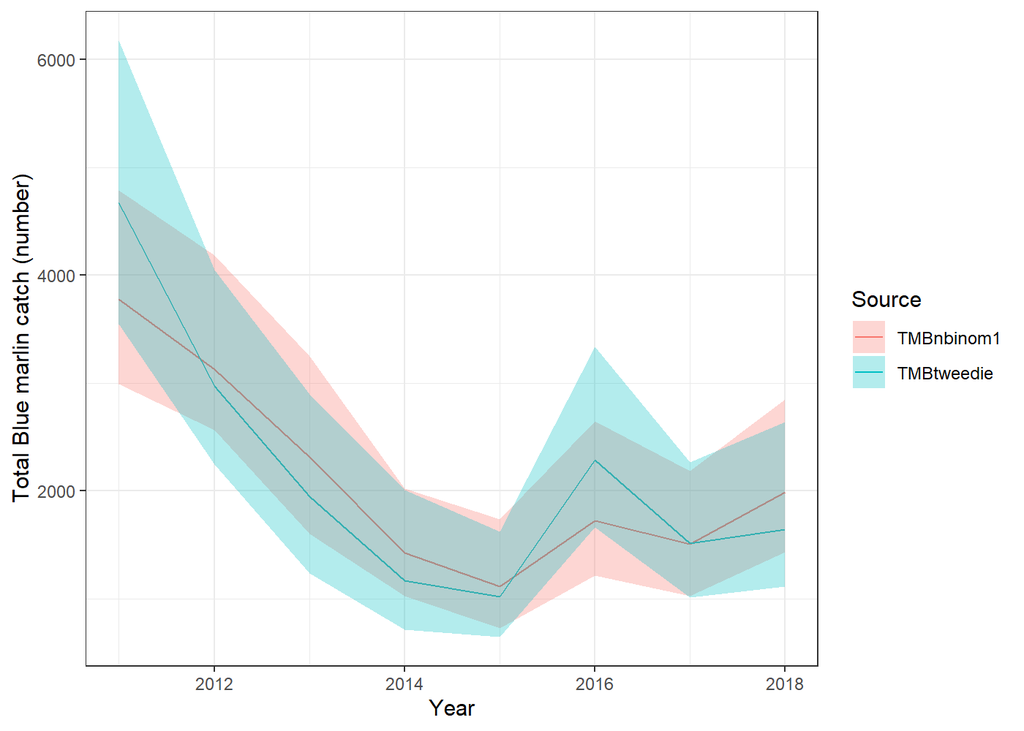

Figure 1. Total bycatch estimates for all valid models, for Blue marlin, with 95% confidence interval calculated by Monte Carlo simulation.

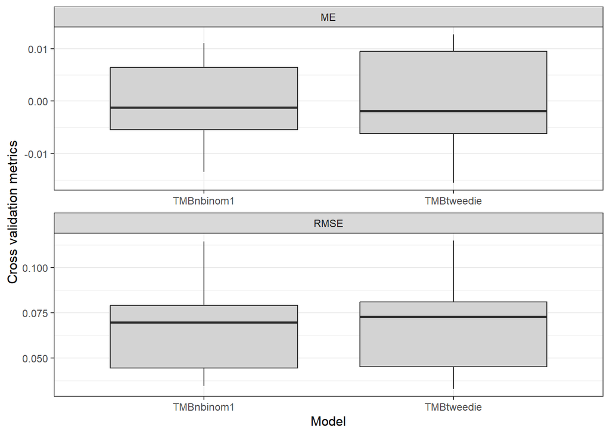

Figure 2. Boxplots of Root Mean Square Error and Mean Error, across 10 cross- validation folds for Blue marlin. Lowest RMSE model is TMBnbinom1.

## Results for each model type

Table 4. Model selection table for TMBnbinom1. Weights are calculated based on BIC.

|  | Int | area | Year | AICc | AIC | BIC | df | logLik | selectCriteria | delta | weight | R2 |
| --- | --- | --- | --- | --- | --- | --- | --- | --- | --- | --- | --- | --- |
| 1 | -2.2 | + | + | 1226.9 | 1226.3 | 1265.2 | 10 | -603.1 | 1265.2 | 0.0 | 1 | 0.13 |
| 0 | -2.8 | NA | + | 1321.2 | 1320.7 | 1355.7 | 9 | -651.3 | 1355.7 | 90.5 | 0 | 0.03 |

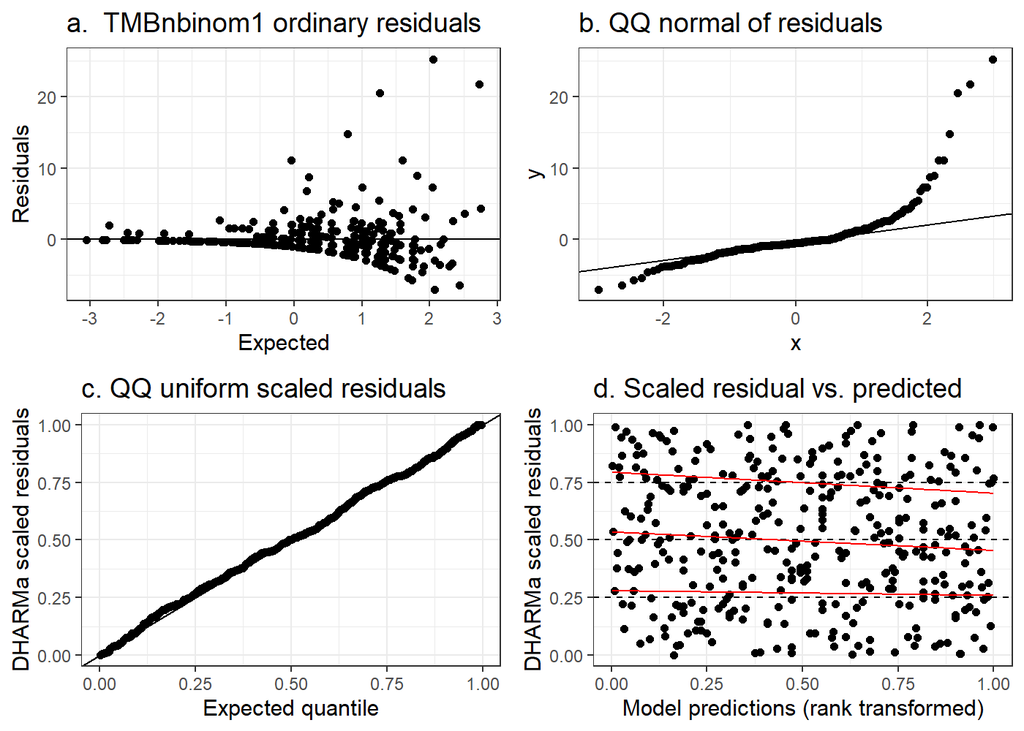

Figure 3. Residuals for the BIC best model for TMBnbinom1, showing the ordinary residuals (a,b) and DHARMa scaled residuals (c,d).

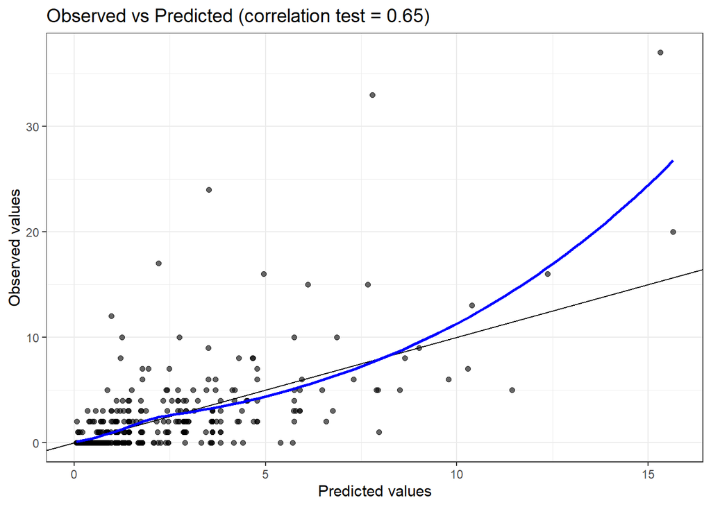

Figure 4. Observed vs predicted values for TMBnbinom1.

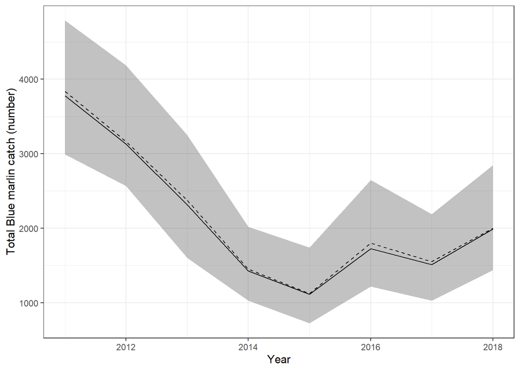

Figure 5. Estimated total bycatch from TMBnbinom1, with 95% confidence interval calculated by Monte Carlo simulation. Solid line is the best estimate and dashed line is the mean across simulations.

Table 5. Model selection table for TMBtweedie. Weights are calculated based on BIC.

|  | Int | area | Year | AICc | AIC | BIC | df | logLik | selectCriteria | delta | weight | R2 |
| --- | --- | --- | --- | --- | --- | --- | --- | --- | --- | --- | --- | --- |
| 1 | -2.0 | + | + | -204.7 | -205.4 | -162.6 | 11 | 113.7 | -162.6 | 0.0 | 1 | 0.13 |
| 0 | -2.6 | NA | + | -158.1 | -158.7 | -119.8 | 10 | 89.3 | -119.8 | 42.8 | 0 | 0.05 |

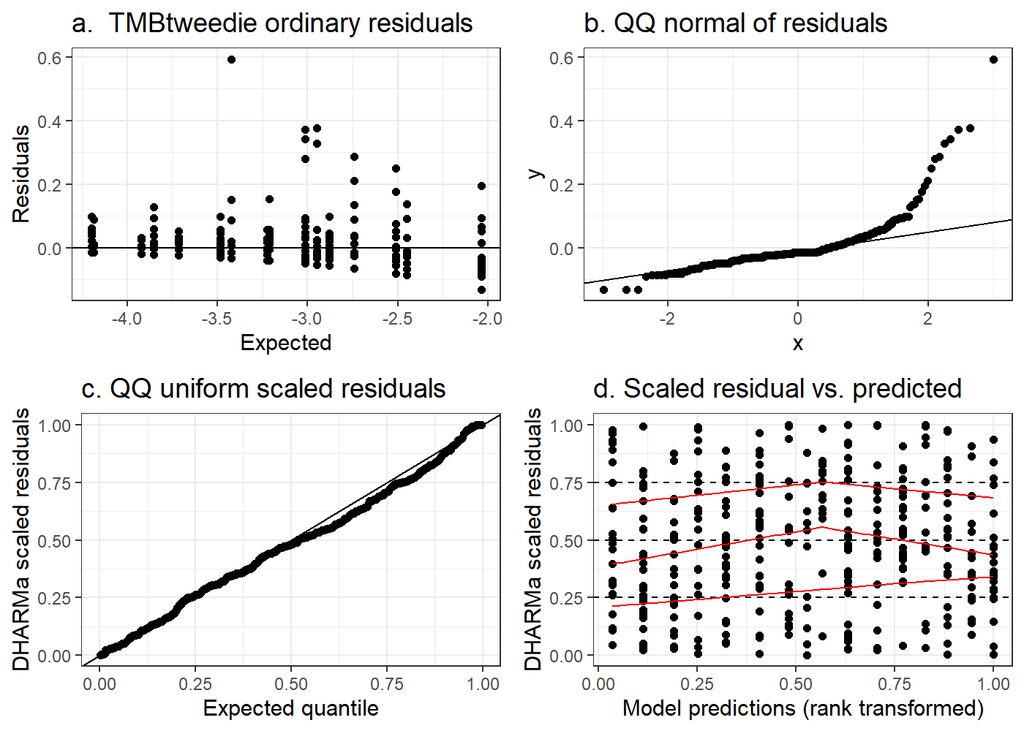

Figure 6. Residuals for the BIC best model for TMBtweedie, showing the ordinary residuals (a,b) and DHARMa scaled residuals (c,d).

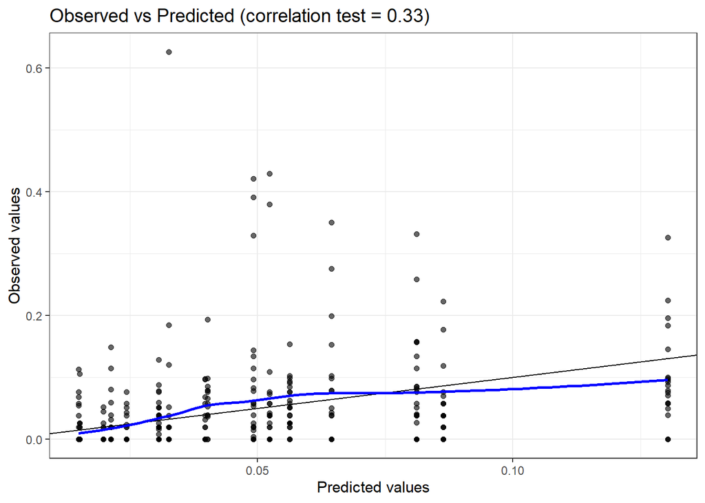

Figure 7. Observed vs predicted values for TMBtweedie.

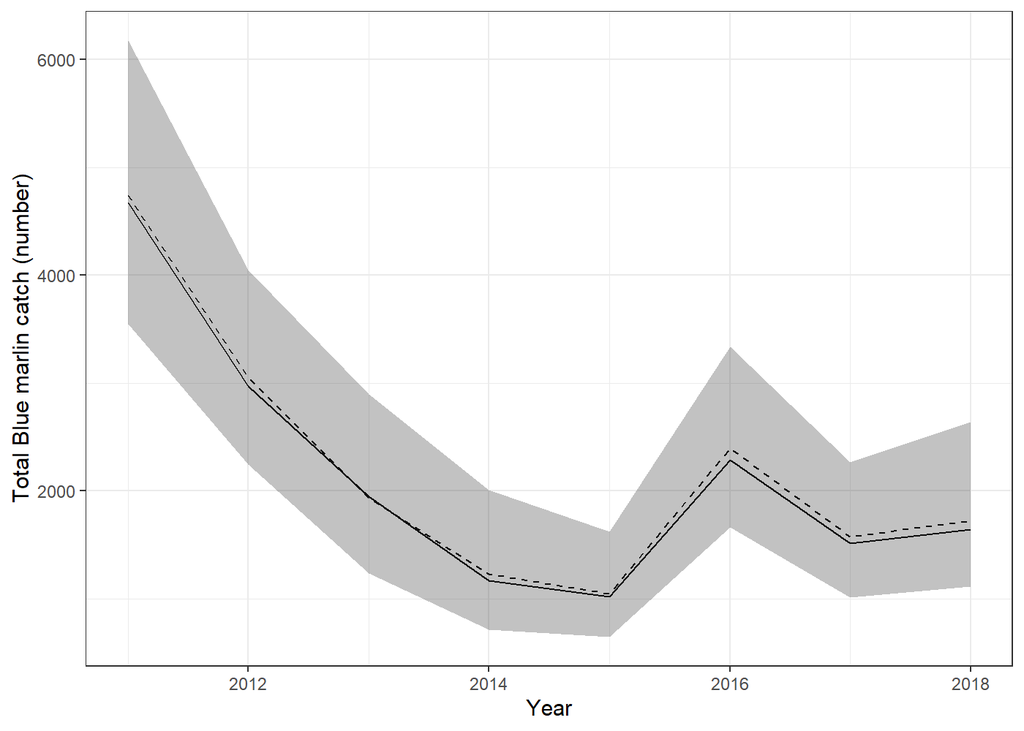

Figure 8. Estimated total bycatch from TMBtweedie, with 95% confidence interval calculated by Monte Carlo simulation. Solid line is the best estimate and dashed line is the mean across simulations.